# hw8

Hui Sophie Wang

# 14.20

## (a)

```r
data <- read.table("https://netfiles.umn.edu/users/nacht001/www/nachtsheim/5th/KutnerData/Chapter%2014%20Data%20Sets/CH14PR14.txt", col.names=c("Y", "X1", "X2", "X3"))
Y <- data$Y
X1 <- data$X1
X2 <- data$X2
X3 <- data$X3

fit <- glm(Y~X1+X2+X3, family=binomial)
summary(fit)
```

```
##
## Call:
## glm(formula = Y ~ X1 + X2 + X3, family = binomial)
##
## Deviance Residuals:
##     Min       1Q   Median       3Q      Max
## -1.4037  -0.5637  -0.3352  -0.1542   2.9394
##
## Coefficients:
##             Estimate Std. Error z value Pr(>|z|)
## (Intercept) -1.17716    2.98242  -0.395  0.69307
## X1           0.07279    0.03038   2.396  0.01658 *
## X2          -0.09899    0.03348  -2.957  0.00311 **
## X3           0.43397    0.52179   0.832  0.40558
## ---
## Signif. codes:  0 '***' 0.001 '**' 0.01 '*' 0.05 '.' 0.1 ' ' 1
##
## (Dispersion parameter for binomial family taken to be 1)
##
##     Null deviance: 134.94  on 158  degrees of freedom
## Residual deviance: 105.09  on 155  degrees of freedom
## AIC: 113.09
##
## Number of Fisher Scoring iterations: 6
```

For Bonferroni Confidence Interval $B=Z^{1-\alpha/2g}$, $\alpha=0.1$, $g=2$, so $B=Z^{0.975}=1.96$

$s^2\{b_1\}=0.0304$

CI of $\beta_1$ is $0.073\pm1.96*0.0304=[0.013, 0.133]$

CI of $exp(30\beta_1)$ is $[1.48, 54]$

$s^2\{b_2\}=0.0335$

CI of $\beta_2$ is $-0.099\pm1.96*0.0335=[-0.165, -0.0333]$

CI of $exp(25\beta_2)$ is $[0.016, 0.435]$

Interpretation: With family confidence coefficient 0.9, we conclude that age odds ratio for males whose ages differ by 30 years falls between [1.48, 54], and health awareness index odds ratio for males whose health awareness index differ by 25 falls between [0.016, 0.435]

## (b)

Hypothesis:

$H_0:\beta_3=0$

$H_a:\beta_3\neq{0}$

Decision rule:

If $|z^*|<z^{0.975}$, conclude $H_0$, else, conclude $H_a$

$z^*=b_3/s^2\{b_3\}=0.4334/0.5218=0.83$

$z^{0.975}=1.96$, ince $z^*<z^{0.975}$, we conclude $H_0$

p-value is 0.406

## (c)

Hypothesis:

$H_0:\beta_3=0$ (Reduced Model)

$H_a:\beta_3\neq{0}$ (Full Model)

Decision rule:

If $G^2<\chi^2(0.95, 1)$, conclude $H_0$, else, conclude $H_a$

```r
pi_prime <- cbind(1, X1, X2, X3) %*% coef(fit)
log_lf <- sum(Y*pi_prime) - sum(log(1+exp(pi_prime)))

fit_r <- glm(Y~X1+X2, family=binomial)
pi_prime_r <- cbind(1, X1, X2) %*% coef(fit_r)
log_lr <- sum(Y*pi_prime_r) - sum(log(1+exp(pi_prime_r)))

(-2)*(log_lr-log_lf)
```

```
## [1] 0.7022111
```

$G^2=0.7$

$\chi^2(0.95, 1)=3.841$, since $G^2<\chi^2(0.95, 1)$, we conclude $H_0$

p-value is 0.403

The p-value obtained from likelihood ratio test and Wald test are very close. And they lead to the same conclusion.

## (d)

$X\beta=\beta_0+X_1\beta_1+X_2\beta_2+X_1^2\beta_3+X_2^2\beta_4+X_1X_2\beta_5$

Hypothesis:

$H_0:\beta_3=\beta_4=\beta_5=0$ (Reduced Model)

$H_a$ :not all the $\beta$ in $H_0$ is zero (Full Model)

Decision rule:

If $G^2<\chi^2(0.95, 3)$, conclude $H_0$, else, conclude $H_a$

```r
X11 <- X1^2
X22 <- X2^2
X12 <- X1*X2
X21 <- X2*X1
fit2 <- glm(Y~X1+X2+X11+X22+X12, family=binomial)
pi_prime2 <- cbind(1, X1, X2, X11, X22, X12) %*% coef(fit2)
log_l2 <- sum(Y*pi_prime2) - sum(log(1+exp(pi_prime2)))

(-2)*(log_lr-log_l2)
```

```
## [1] 1.533954
```

$G^2=1.534$

$\chi^2(0.95, 1)=7.815$, since $G^2<\chi^2(0.95, 3)$, we conclude $H_0$, second order terms should not be added.

p-value is 0.674

# 14.22

## (a)

$X\beta=\beta_0+X_1\beta_1+X_2\beta_2+X_3\beta_3+X_1^2\beta_4+X_2^2\beta_5+X_1X_2\beta_6$

```r
fit_x1 <- glm(Y~X1, family=binomial)
summary(fit_x1)
```

```
##
## Call:
## glm(formula = Y ~ X1, family = binomial)
##
## Deviance Residuals:
##     Min       1Q   Median       3Q      Max
## -1.3472  -0.6008  -0.3688  -0.2683   2.5447
##
## Coefficients:
##             Estimate Std. Error z value Pr(>|z|)
## (Intercept) -8.74326    1.85307  -4.718 2.38e-06 ***
## X1           0.10874    0.02737   3.973 7.08e-05 ***
## ---
## Signif. codes:  0 '***' 0.001 '**' 0.01 '*' 0.05 '.' 0.1 ' ' 1
##
## (Dispersion parameter for binomial family taken to be 1)
##
##     Null deviance: 134.94  on 158  degrees of freedom
## Residual deviance: 116.27  on 157  degrees of freedom
## AIC: 120.27
##
## Number of Fisher Scoring iterations: 5
```

```r
fit_x2 <- glm(Y~X2, family=binomial)
summary(fit_x2)
```

```
##
## Call:
## glm(formula = Y ~ X2, family = binomial)
##
## Deviance Residuals:
##     Min       1Q   Median       3Q      Max
## -1.3944  -0.5926  -0.3999  -0.2369   2.8476
##
## Coefficients:
##             Estimate Std. Error z value Pr(>|z|)
## (Intercept)  4.91133    1.62651    3.02  0.00253 **
## X2          -0.11931    0.03013   -3.96  7.5e-05 ***
## ---
## Signif. codes:  0 '***' 0.001 '**' 0.01 '*' 0.05 '.' 0.1 ' ' 1
##
## (Dispersion parameter for binomial family taken to be 1)
##
##     Null deviance: 134.94  on 158  degrees of freedom
## Residual deviance: 113.20  on 157  degrees of freedom
## AIC: 117.2
##
## Number of Fisher Scoring iterations: 5
```

```r
fit_x3 <- glm(Y~X3, family=binomial)
summary(fit_x3)
```

```
##
## Call:
## glm(formula = Y ~ X3, family = binomial)
##
## Deviance Residuals:
##     Min       1Q   Median       3Q      Max
## -0.6536  -0.6536  -0.4854  -0.4854   2.0963
##
## Coefficients:
##             Estimate Std. Error z value Pr(>|z|)
## (Intercept)  -2.0794     0.3535  -5.882 4.06e-09 ***
## X3            0.6444     0.4556   1.414    0.157
## ---
## Signif. codes:  0 '***' 0.001 '**' 0.01 '*' 0.05 '.' 0.1 ' ' 1
##
## (Dispersion parameter for binomial family taken to be 1)
##
##     Null deviance: 134.94  on 158  degrees of freedom
## Residual deviance: 132.88  on 157  degrees of freedom
## AIC: 136.88
##
## Number of Fisher Scoring iterations: 4
```

```r
fit_x11 <- glm(Y~X11, family=binomial)
summary(fit_x11)
```

```
##
## Call:
## glm(formula = Y ~ X11, family = binomial)
##
## Deviance Residuals:
##     Min       1Q   Median       3Q      Max
## -1.4230  -0.5844  -0.3753  -0.2921   2.4890
##
## Coefficients:
##               Estimate Std. Error z value Pr(>|z|)
## (Intercept) -5.1604489  0.9509507  -5.427 5.74e-08 ***
## X11          0.0008109  0.0002021   4.011 6.03e-05 ***
## ---
## Signif. codes:  0 '***' 0.001 '**' 0.01 '*' 0.05 '.' 0.1 ' ' 1
##
## (Dispersion parameter for binomial family taken to be 1)
##
##     Null deviance: 134.94  on 158  degrees of freedom
## Residual deviance: 116.62  on 157  degrees of freedom
## AIC: 120.62
##
## Number of Fisher Scoring iterations: 5
```

```r
fit_x22 <- glm(Y~X22, family=binomial)
summary(fit_x22)
```

```
##
## Call:
## glm(formula = Y ~ X22, family = binomial)
##
## Deviance Residuals:
##     Min       1Q   Median       3Q      Max
## -1.2815  -0.6123  -0.4012  -0.2109   2.9828
##
## Coefficients:
##               Estimate Std. Error z value Pr(>|z|)
## (Intercept)  1.7461291  0.8557812   2.040 0.041311 *
## X22         -0.0010992  0.0002862  -3.841 0.000123 ***
## ---
## Signif. codes:  0 '***' 0.001 '**' 0.01 '*' 0.05 '.' 0.1 ' ' 1
##
## (Dispersion parameter for binomial family taken to be 1)
##
##     Null deviance: 134.94  on 158  degrees of freedom
## Residual deviance: 114.28  on 157  degrees of freedom
## AIC: 118.28
##
## Number of Fisher Scoring iterations: 5
```

```r
fit_x12 <- glm(Y~X12, family=binomial)
summary(fit_x12)
```

```
##
## Call:
## glm(formula = Y ~ X12, family = binomial)
##
## Deviance Residuals:
##     Min       1Q   Median       3Q      Max
## -0.7200  -0.5974  -0.5547  -0.4995   2.1672
##
## Coefficients:
##               Estimate Std. Error z value Pr(>|z|)
## (Intercept) -0.2736876  1.3402216  -0.204    0.838
## X12         -0.0004113  0.0003792  -1.085    0.278
##
## (Dispersion parameter for binomial family taken to be 1)
##
##     Null deviance: 134.94  on 158  degrees of freedom
## Residual deviance: 133.75  on 157  degrees of freedom
## AIC: 137.75
##
## Number of Fisher Scoring iterations: 4
```

Step 1: X11 is added

```r
fit_x11x1 <- glm(Y~X11+X1, family=binomial)
summary(fit_x11x1)
```

```
##
## Call:
## glm(formula = Y ~ X11 + X1, family = binomial)
##
## Deviance Residuals:
##     Min       1Q   Median       3Q      Max
## -1.2179  -0.6264  -0.3608  -0.2374   2.6226
##
## Coefficients:
##               Estimate Std. Error z value Pr(>|z|)
## (Intercept) -14.227115  12.599354  -1.129    0.259
## X11          -0.001263   0.002850  -0.443    0.658
## X1            0.276575   0.380874   0.726    0.468
##
## (Dispersion parameter for binomial family taken to be 1)
##
##     Null deviance: 134.94  on 158  degrees of freedom
## Residual deviance: 116.07  on 156  degrees of freedom
## AIC: 122.07
##
## Number of Fisher Scoring iterations: 6
```

```r
fit_x11x2 <- glm(Y~X11+X2, family=binomial)
summary(fit_x11x2)
```

```
##
## Call:
## glm(formula = Y ~ X11 + X2, family = binomial)
##
## Deviance Residuals:
##     Min       1Q   Median       3Q      Max
## -1.4373  -0.5746  -0.3504  -0.1739   2.8476
##
## Coefficients:
##               Estimate Std. Error z value Pr(>|z|)
## (Intercept)  1.1429547  2.1864410   0.523  0.60115
## X11          0.0005785  0.0002202   2.627  0.00861 **
## X2          -0.0959118  0.0322603  -2.973  0.00295 **
## ---
## Signif. codes:  0 '***' 0.001 '**' 0.01 '*' 0.05 '.' 0.1 ' ' 1
##
## (Dispersion parameter for binomial family taken to be 1)
##
##     Null deviance: 134.94  on 158  degrees of freedom
## Residual deviance: 105.93  on 156  degrees of freedom
## AIC: 111.93
##
## Number of Fisher Scoring iterations: 6
```

```r
fit_x11x3 <- glm(Y~X11+X3, family=binomial)
summary(fit_x11x3)
```

```
##
## Call:
## glm(formula = Y ~ X11 + X3, family = binomial)
##
## Deviance Residuals:
##     Min       1Q   Median       3Q      Max
## -1.4644  -0.5753  -0.3920  -0.2820   2.5473
##
## Coefficients:
##               Estimate Std. Error z value Pr(>|z|)
## (Intercept) -5.2569520  0.9693381  -5.423 5.85e-08 ***
## X11          0.0007891  0.0002043   3.862 0.000113 ***
## X3           0.3426300  0.4892107   0.700 0.483694
## ---
## Signif. codes:  0 '***' 0.001 '**' 0.01 '*' 0.05 '.' 0.1 ' ' 1
##
## (Dispersion parameter for binomial family taken to be 1)
##
##     Null deviance: 134.94  on 158  degrees of freedom
## Residual deviance: 116.12  on 156  degrees of freedom
## AIC: 122.12
##
## Number of Fisher Scoring iterations: 5
```

```r
fit_x11x22 <- glm(Y~X11+X22, family=binomial)
summary(fit_x11x22)
```

```
##
## Call:
## glm(formula = Y ~ X11 + X22, family = binomial)
##
## Deviance Residuals:
##     Min       1Q   Median       3Q      Max
## -1.3381  -0.5819  -0.3517  -0.1589   2.9472
##
## Coefficients:
##               Estimate Std. Error z value Pr(>|z|)
## (Intercept) -1.4623971  1.4962619  -0.977  0.32839
## X11          0.0005835  0.0002203   2.649  0.00807 **
## X22         -0.0008708  0.0003055  -2.851  0.00436 **
## ---
## Signif. codes:  0 '***' 0.001 '**' 0.01 '*' 0.05 '.' 0.1 ' ' 1
##
## (Dispersion parameter for binomial family taken to be 1)
##
##     Null deviance: 134.94  on 158  degrees of freedom
## Residual deviance: 106.86  on 156  degrees of freedom
## AIC: 112.86
##
## Number of Fisher Scoring iterations: 6
```

```r
fit_x11x12 <- glm(Y~X11+X12, family=binomial)
summary(fit_x11x12)
```

```
##
## Call:
## glm(formula = Y ~ X11 + X12, family = binomial)
##
## Deviance Residuals:
##     Min       1Q   Median       3Q      Max
## -1.4488  -0.5495  -0.3633  -0.2207   2.7611
##
## Coefficients:
##               Estimate Std. Error z value Pr(>|z|)
## (Intercept) -1.6465775  1.4812752  -1.112  0.26631
## X11          0.0011511  0.0002530   4.549 5.39e-06 ***
## X12         -0.0013898  0.0004865  -2.857  0.00428 **
## ---
## Signif. codes:  0 '***' 0.001 '**' 0.01 '*' 0.05 '.' 0.1 ' ' 1
##
## (Dispersion parameter for binomial family taken to be 1)
##
##     Null deviance: 134.94  on 158  degrees of freedom
## Residual deviance: 106.59  on 156  degrees of freedom
## AIC: 112.59
##
## Number of Fisher Scoring iterations: 5
```

Step 2: X2 is added

```r
fit_x11x2x1 <- glm(Y~X11+X2+X1, family=binomial)
summary(fit_x11x2x1)
```

```
##
## Call:
## glm(formula = Y ~ X11 + X2 + X1, family = binomial)
##
## Deviance Residuals:
##     Min       1Q   Median       3Q      Max
## -1.4617  -0.5585  -0.3341  -0.1493   2.8379
##
## Coefficients:
##               Estimate Std. Error z value Pr(>|z|)
## (Intercept) -4.7964239 13.4988876  -0.355  0.72235
## X11         -0.0007632  0.0030053  -0.254  0.79954
## X2          -0.0953140  0.0325603  -2.927  0.00342 **
## X1           0.1795365  0.4019927   0.447  0.65515
## ---
## Signif. codes:  0 '***' 0.001 '**' 0.01 '*' 0.05 '.' 0.1 ' ' 1
##
## (Dispersion parameter for binomial family taken to be 1)
##
##     Null deviance: 134.94  on 158  degrees of freedom
## Residual deviance: 105.73  on 155  degrees of freedom
## AIC: 113.73
##
## Number of Fisher Scoring iterations: 6
```

```r
fit_x11x2x3 <- glm(Y~X11+X2+X3, family=binomial)
summary(fit_x11x2x3)
```

```
##
## Call:
## glm(formula = Y ~ X11 + X2 + X3, family = binomial)
##
## Deviance Residuals:
##     Min       1Q   Median       3Q      Max
## -1.3900  -0.5589  -0.3420  -0.1598   2.9446
##
## Coefficients:
##               Estimate Std. Error z value Pr(>|z|)
## (Intercept)  1.2520463  2.2363794   0.560  0.57558
## X11          0.0005405  0.0002255   2.396  0.01656 *
## X2          -0.0994065  0.0333400  -2.982  0.00287 **
## X3           0.4393013  0.5217332   0.842  0.39979
## ---
## Signif. codes:  0 '***' 0.001 '**' 0.01 '*' 0.05 '.' 0.1 ' ' 1
##
## (Dispersion parameter for binomial family taken to be 1)
##
##     Null deviance: 134.94  on 158  degrees of freedom
## Residual deviance: 105.21  on 155  degrees of freedom
## AIC: 113.21
##
## Number of Fisher Scoring iterations: 6
```

```r
fit_x11x2x22 <- glm(Y~X11+X2+X22, family=binomial)
summary(fit_x11x2x22)
```

```
##
## Call:
## glm(formula = Y ~ X11 + X2 + X22, family = binomial)
##
## Deviance Residuals:
##     Min       1Q   Median       3Q      Max
## -1.6572  -0.5462  -0.3413  -0.2248   2.5579
##
## Coefficients:
##               Estimate Std. Error z value Pr(>|z|)
## (Intercept)  7.1730651  7.0443462   1.018  0.30855
## X11          0.0005974  0.0002220   2.691  0.00713 **
## X2          -0.3280695  0.2534115  -1.295  0.19545
## X22          0.0021546  0.0022695   0.949  0.34243
## ---
## Signif. codes:  0 '***' 0.001 '**' 0.01 '*' 0.05 '.' 0.1 ' ' 1
##
## (Dispersion parameter for binomial family taken to be 1)
##
##     Null deviance: 134.94  on 158  degrees of freedom
## Residual deviance: 105.04  on 155  degrees of freedom
## AIC: 113.04
##
## Number of Fisher Scoring iterations: 6
```

```r
fit_x11x2x12 <- glm(Y~X11+X2+X12, family=binomial)
summary(fit_x11x2x12)
```

```
##
## Call:
## glm(formula = Y ~ X11 + X2 + X12, family = binomial)
##
## Deviance Residuals:
##     Min       1Q   Median       3Q      Max
## -1.4092  -0.5878  -0.3398  -0.1413   2.9053
##
## Coefficients:
##               Estimate Std. Error z value Pr(>|z|)
## (Intercept)  3.2404769  5.8761463   0.551    0.581
## X11          0.0001181  0.0012025   0.098    0.922
## X2          -0.1726627  0.2025071  -0.853    0.394
## X12          0.0011508  0.0029727   0.387    0.699
##
## (Dispersion parameter for binomial family taken to be 1)
##
##     Null deviance: 134.94  on 158  degrees of freedom
## Residual deviance: 105.78  on 155  degrees of freedom
## AIC: 113.78
##
## Number of Fisher Scoring iterations: 6
```

Step 3: no predictor is added, stop

Final model contains X2, X11

## (b)

```r
fit_all <- glm(Y~X1+X2+X3+X11+X22+X12, family=binomial)
summary(fit_all)
```

```
##
## Call:
## glm(formula = Y ~ X1 + X2 + X3 + X11 + X22 + X12, family = binomial)
##
## Deviance Residuals:
##     Min       1Q   Median       3Q      Max
## -1.7540  -0.5678  -0.3189  -0.1609   2.6012
##
## Coefficients:
##               Estimate Std. Error z value Pr(>|z|)
## (Intercept) 19.6040080 24.1905242   0.810    0.418
## X1          -0.0331617  0.4878396  -0.068    0.946
## X2          -0.7529410  0.4877503  -1.544    0.123
## X3           0.6200280  0.5543139   1.119    0.263
## X11         -0.0005456  0.0030897  -0.177    0.860
## X22          0.0040101  0.0028771   1.394    0.163
## X12          0.0033484  0.0037970   0.882    0.378
##
## (Dispersion parameter for binomial family taken to be 1)
##
##     Null deviance: 134.94  on 158  degrees of freedom
## Residual deviance: 102.97  on 152  degrees of freedom
## AIC: 116.97
##
## Number of Fisher Scoring iterations: 6
```

Step 1: X1 is removed

```r
fit_no_x1 <- glm(Y~X2+X3+X11+X22+X12, family=binomial)
summary(fit_no_x1)
```

```
##
## Call:
## glm(formula = Y ~ X2 + X3 + X11 + X22 + X12, family = binomial)
##
## Deviance Residuals:
##     Min       1Q   Median       3Q      Max
## -1.7594  -0.5676  -0.3165  -0.1600   2.5960
##
## Coefficients:
##               Estimate Std. Error z value Pr(>|z|)
## (Intercept) 18.1882504 12.3878000   1.468    0.142
## X2          -0.7408476  0.4561153  -1.624    0.104
## X3           0.6153310  0.5497318   1.119    0.263
## X11         -0.0007362  0.0012979  -0.567    0.571
## X22          0.0039845  0.0028582   1.394    0.163
## X12          0.0032069  0.0031917   1.005    0.315
##
## (Dispersion parameter for binomial family taken to be 1)
##
##     Null deviance: 134.94  on 158  degrees of freedom
## Residual deviance: 102.97  on 153  degrees of freedom
## AIC: 114.97
##
## Number of Fisher Scoring iterations: 6
```

Step 2: X11 is removed

```r
fit_no_x1x11 <- glm(Y~X2+X3+X22+X12, family=binomial)
summary(fit_no_x1x11)
```

```
##
## Call:
## glm(formula = Y ~ X2 + X3 + X22 + X12, family = binomial)
##
## Deviance Residuals:
##     Min       1Q   Median       3Q      Max
## -1.6825  -0.5518  -0.3284  -0.1912   2.6035
##
## Coefficients:
##               Estimate Std. Error z value Pr(>|z|)
## (Intercept) 12.7147869  7.4352343   1.710  0.08725 .
## X2          -0.5410042  0.2779856  -1.946  0.05164 .
## X3           0.5608302  0.5391480   1.040  0.29824
## X22          0.0032296  0.0024237   1.333  0.18270
## X12          0.0014326  0.0005548   2.582  0.00982 **
## ---
## Signif. codes:  0 '***' 0.001 '**' 0.01 '*' 0.05 '.' 0.1 ' ' 1
##
## (Dispersion parameter for binomial family taken to be 1)
##
##     Null deviance: 134.94  on 158  degrees of freedom
## Residual deviance: 103.30  on 154  degrees of freedom
## AIC: 113.3
##
## Number of Fisher Scoring iterations: 6
```

Step 3: X3 is removed

```r
fit_no_x1x11x3 <- glm(Y~X2+X22+X12, family=binomial)
summary(fit_no_x1x11x3)
```

```
##
## Call:
## glm(formula = Y ~ X2 + X22 + X12, family = binomial)
##
## Deviance Residuals:
##     Min       1Q   Median       3Q      Max
## -1.6667  -0.5747  -0.3252  -0.1922   2.5344
##
## Coefficients:
##               Estimate Std. Error z value Pr(>|z|)
## (Intercept) 11.5290585  7.2989509   1.580  0.11421
## X2          -0.4939979  0.2726161  -1.812  0.06998 .
## X22          0.0027780  0.0023819   1.166  0.24350
## X12          0.0015195  0.0005443   2.792  0.00524 **
## ---
## Signif. codes:  0 '***' 0.001 '**' 0.01 '*' 0.05 '.' 0.1 ' ' 1
##
## (Dispersion parameter for binomial family taken to be 1)
##
##     Null deviance: 134.94  on 158  degrees of freedom
## Residual deviance: 104.41  on 155  degrees of freedom
## AIC: 112.41
##
## Number of Fisher Scoring iterations: 6
```

Step 4: X22 is removed

```r
fit_no_x1x11x3x22 <- glm(Y~X2+X12, family=binomial)
summary(fit_no_x1x11x3x22)
```

```
##
## Call:
## glm(formula = Y ~ X2 + X12, family = binomial)
##
## Deviance Residuals:
##     Min       1Q   Median       3Q      Max
## -1.4032  -0.5908  -0.3411  -0.1338   2.9209
##
## Coefficients:
##               Estimate Std. Error z value Pr(>|z|)
## (Intercept)  3.7940936  1.7153339   2.212  0.02698 *
## X2          -0.1921435  0.0446318  -4.305 1.67e-05 ***
## X12          0.0014384  0.0005467   2.631  0.00851 **
## ---
## Signif. codes:  0 '***' 0.001 '**' 0.01 '*' 0.05 '.' 0.1 ' ' 1
##
## (Dispersion parameter for binomial family taken to be 1)
##
##     Null deviance: 134.94  on 158  degrees of freedom
## Residual deviance: 105.79  on 156  degrees of freedom
## AIC: 111.79
##
## Number of Fisher Scoring iterations: 6
```

Step 5: no predictor is removed, stop

Final model contains X2 and X12.

# 14.28

## (a)

```r
fit_x1x2 <- glm(Y~X1+X2, family=binomial)
summary(fit_x1x2)
```

```
##
## Call:
## glm(formula = Y ~ X1 + X2, family = binomial)
##
## Deviance Residuals:
##     Min       1Q   Median       3Q      Max
## -1.4479  -0.5708  -0.3390  -0.1629   2.8430
##
## Coefficients:
##             Estimate Std. Error z value Pr(>|z|)
## (Intercept) -1.45778    2.91534  -0.500  0.61705
## X1           0.07787    0.02970   2.622  0.00873 **
## X2          -0.09547    0.03241  -2.946  0.00322 **
## ---
## Signif. codes:  0 '***' 0.001 '**' 0.01 '*' 0.05 '.' 0.1 ' ' 1
##
## (Dispersion parameter for binomial family taken to be 1)
##
##     Null deviance: 134.94  on 158  degrees of freedom
## Residual deviance: 105.80  on 156  degrees of freedom
## AIC: 111.8
##
## Number of Fisher Scoring iterations: 6
```

```r
pi_prime <- cbind(1, X1, X2) %*% coef(fit_x1x2)

res <- cbind(Y, pi_prime)
res <- res[order(res[,2], res[,1]),]

for(j in c(1:7)){
  start <- (j-1)*20+1
  end <- start + 19
  m <- (res[start,2]+res[end,2])/2
  print(m)
  p <- 1.0/(1+exp(-m))
  print(p)
  count <- sum(res[start:end,1])
  print(count)
}
```

```
##
## -4.816324
##
## 0.008031467
## [1] 0
##
## -3.63172
##
## 0.02578798
## [1] 1
##
## -2.958351
##
## 0.04934332
## [1] 0
##
## -2.46098
##
## 0.07863928
## [1] 2
##
## -1.931065
##
## 0.1266328
## [1] 2
##
## -1.517712
##
## 0.1797987
## [1] 7
##
## -1.091823
##
## 0.2512752
## [1] 2
```

```r
m8 <- (res[141,2]+res[159,2])/2
m8
```

```
##
## 0.7648232
```

```r
1.0/(1+exp(-m8))
```

```
##
## 0.6824
```

```r
sum(res[141:159,1])
```

```
## [1] 10
```

[output not shown]

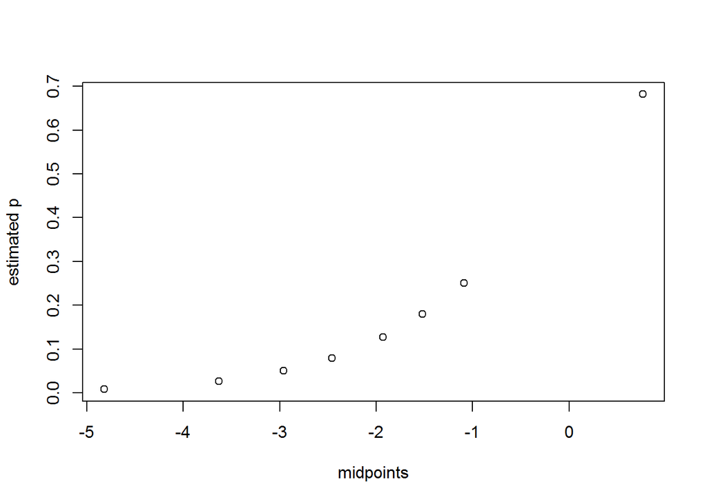

```r
m <- c(-4.82, -3.63, -2.96, -2.46, -1.93, -1.52, -1.09, 0.765)
p <- c(0.008, 0.026, 0.05, 0.079, 0.127, 0.18, 0.25, 0.682)
plot(m, p, xlab="midpoints", ylab="estimated p")
```

## (b)

Hypothesis:

$H_0:E[Y]=1/(1+exp(-X\beta))$

$H_a:E[Y]\neq{1/(1+exp(-X\beta))}$

Decision rule:

If $\chi^2<\chi^2(0.95, 8-3)$, conclude $H_0$, else, conclude $H_a$

$\chi^2=10.26$

$\chi^2(0.95, 8-3)=11.07$, Since $\chi^2<\chi^2(0.95, 5)$, we conclude $H_0$

p-value is 0.068

## (c)

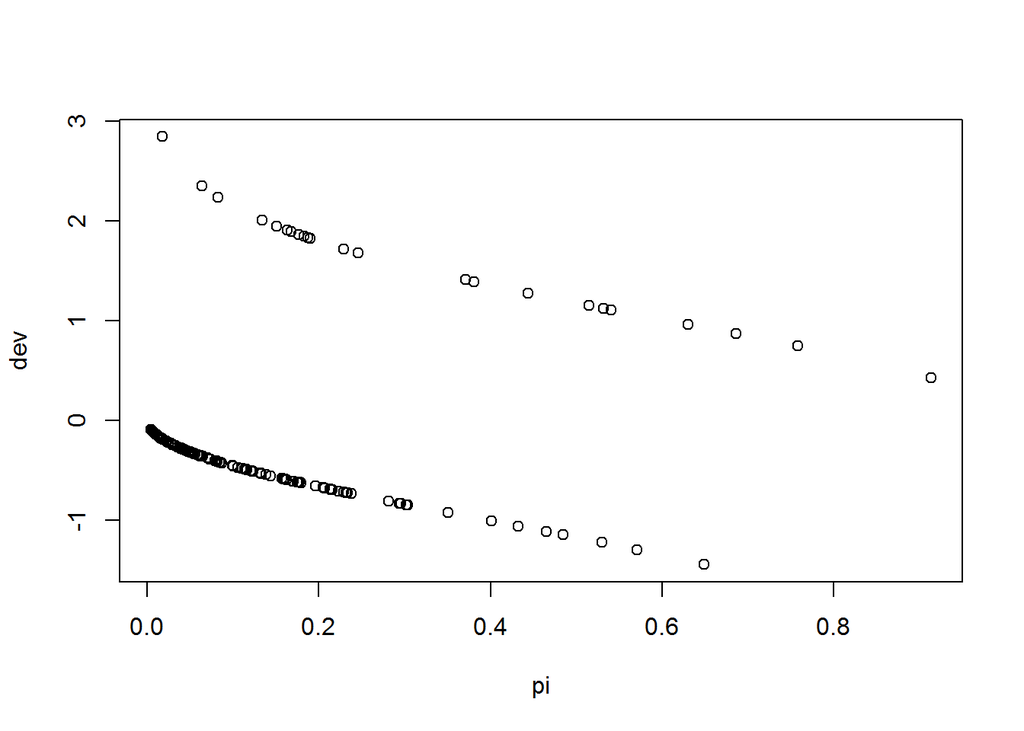

```r
#plot( residuals(fit_x1x2, type="deviance") ~ predict(fit_x1x2, type="response"), xlab=expression(hat(pi)), ylab="Deviance Residual")

pi <- 1.0/(1+exp(-pi_prime))
dev <- (-2)*(Y*log(pi)+(1-Y)*log(1-pi))
sign <- ifelse(Y-pi>0, 1, -1)
dev <- sign*sqrt(dev)
plot(pi, dev)
```

# 14.36

## (a)

```r
fit_all <- glm(Y~X1+X2+X3, family=binomial)
Xh <- cbind(1, 65, 50, 0)
pi_prime <- sum(coef(fit_all)*Xh)
sd <- sqrt(Xh %*% vcov(fit_all) %*% t(Xh))
```

For Bonferroni Confidence Interval $B=Z^{1-\alpha/2g}$, $\alpha=0.1$, $g=1$, so $B=Z^{0.95}=1.645$

L = -1.395-1.645*0.402 = -2.056

U = -1.395+1.645*0.402 = -0.735

$L^*$=1/(1+exp(-L)) = 0.113

$U^*$=1/(1+exp(-U)) = 0.324

## (b)

```r
fit_all <- glm(Y~X1+X2+X3, family=binomial)
pi_prime <- cbind(1, X1, X2, X3) %*% coef(fit_all)
pi <- 1.0/(1+exp(-pi_prime))
Y_hat <- ifelse(pi>0.05, 1, 0)
sum(as.numeric(Y==0 & Y_hat==0))
```

```
## [1] 50
```

```r
sum(as.numeric(Y==0 & Y_hat==1))
```

```
## [1] 85
```

```r
sum(as.numeric(Y==1 & Y_hat==0))
```

```
## [1] 1
```

```r
sum(as.numeric(Y==1 & Y_hat==1))
```

```
## [1] 23
```

cutoff=0.05

| Truth | $\hat{Y}=0$ | $\hat{Y}=1$ | total |
| --- | --- | --- | --- |
| Y=0 | 50 | 85 | 135 |
| Y=1 | 1 | 23 | 24 |
| total | 51 | 108 | 159 |

$total_error_rate$=(1+85)/159=0.54 $Pr(\hat{Y}=0|Y=1)$=1/24=0.042 $Pr(\hat{Y}=1|Y=0)$=85/135=0.63

```r
Y_hat <- ifelse(pi>0.1, 1, 0)
sum(as.numeric(Y==0 & Y_hat==0))
```

```
## [1] 80
```

```r
sum(as.numeric(Y==0 & Y_hat==1))
```

```
## [1] 55
```

```r
sum(as.numeric(Y==1 & Y_hat==0))
```

```
## [1] 3
```

```r
sum(as.numeric(Y==1 & Y_hat==1))
```

```
## [1] 21
```

cutoff=0.1

| Truth | $\hat{Y}=0$ | $\hat{Y}=1$ | total |
| --- | --- | --- | --- |
| Y=0 | 80 | 55 | 135 |
| Y=1 | 3 | 21 | 24 |
| total | 83 | 76 | 159 |

$total_error_rate$=(3+55)/159=0.365 $Pr(\hat{Y}=0|Y=1)$=3/24=0.125 $Pr(\hat{Y}=1|Y=0)$=55/135=0.407

```r
Y_hat <- ifelse(pi>0.15, 1, 0)
sum(as.numeric(Y==0 & Y_hat==0))
```

```
## [1] 97
```

```r
sum(as.numeric(Y==0 & Y_hat==1))
```

```
## [1] 38
```

```r
sum(as.numeric(Y==1 & Y_hat==0))
```

```
## [1] 4
```

```r
sum(as.numeric(Y==1 & Y_hat==1))
```

```
## [1] 20
```

cutoff=0.15

| Truth | $\hat{Y}=0$ | $\hat{Y}=1$ | total |
| --- | --- | --- | --- |
| Y=0 | 97 | 38 | 135 |
| Y=1 | 4 | 20 | 24 |
| total | 101 | 58 | 159 |

$total_error_rate$=(4+38)/159=0.264 $Pr(\hat{Y}=0|Y=1)$=4/24=0.167 $Pr(\hat{Y}=1|Y=0)$=38/135=0.281

```r
Y_hat <- ifelse(pi>0.4, 1, 0)
sum(as.numeric(Y==0 & Y_hat==0))
```

```
## [1] 129
```

```r
sum(as.numeric(Y==0 & Y_hat==1))
```

```
## [1] 6
```

```r
sum(as.numeric(Y==1 & Y_hat==0))
```

```
## [1] 15
```

```r
sum(as.numeric(Y==1 & Y_hat==1))
```

```
## [1] 9
```

[output not shown]

## (c)

```r
library(ROCR)
```

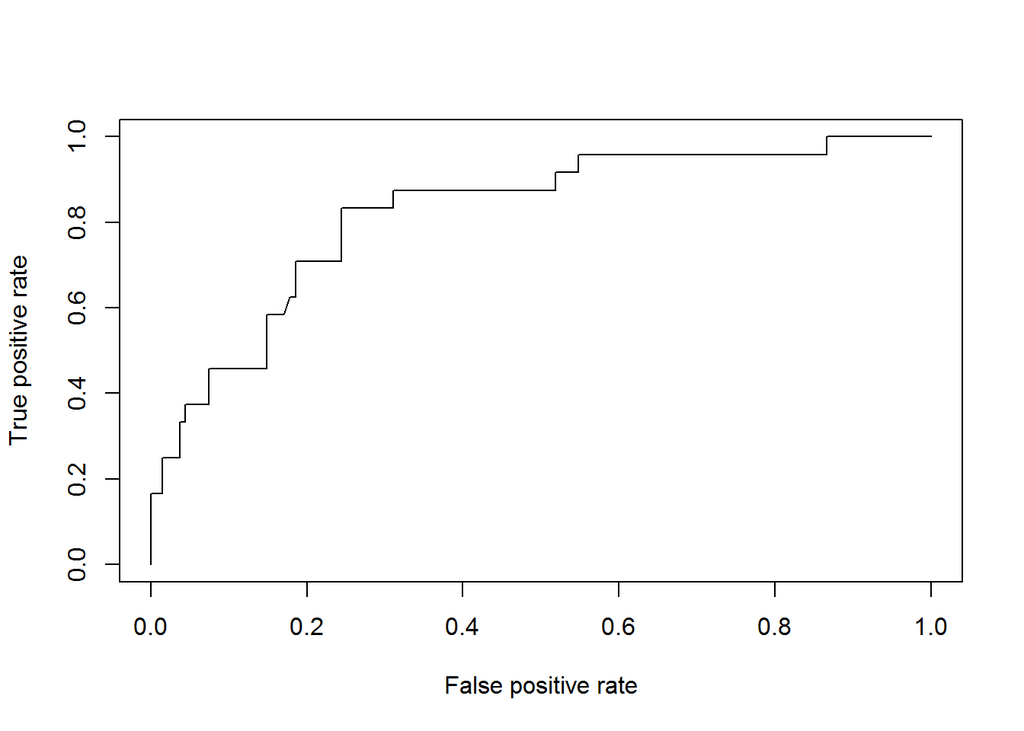

```r
res <- predict(fit_all, type="response")
pred <- prediction(res, labels=Y)
perf <- performance(pred, "tpr", "fpr")
plot(perf, colorize=F)
```

```r
unlist(attributes(performance(pred, "auc"))$y.values)
```

```
## [1] 0.8223765
```

Area under ROC curve is 0.822, which is pretty good, we conclude the model has high predictive power.

## (d)

Should test on a validation data set to verify.

# 11.28

## (a)

```r
X <- c(35, 35, 40, 40, 45, 45, 50, 50, 55, 55, 60, 60)
Y <- c(22, 20, 28, 31, 37, 38, 41, 39, 34, 37, 27, 30)

XX <- X^2
fit <- lm(Y~X+XX)
summary(fit)
```

```
##
## Call:
## lm(formula = Y ~ X + XX)
##
## Residuals:
##      Min       1Q   Median       3Q      Max
## -3.03214 -0.58929  0.03393  1.10893  2.10000
##
## Coefficients:
##               Estimate Std. Error t value Pr(>|t|)
## (Intercept) -1.826e+02  1.768e+01  -10.33 2.73e-06 ***
## X            8.983e+00  7.616e-01   11.80 8.91e-07 ***
## XX          -9.107e-02  7.993e-03  -11.39 1.20e-06 ***
## ---
## Signif. codes:  0 '***' 0.001 '**' 0.01 '*' 0.05 '.' 0.1 ' ' 1
##
## Residual standard error: 1.727 on 9 degrees of freedom
## Multiple R-squared:  0.9474, Adjusted R-squared:  0.9357
## F-statistic: 81.03 on 2 and 9 DF,  p-value: 1.757e-06
```

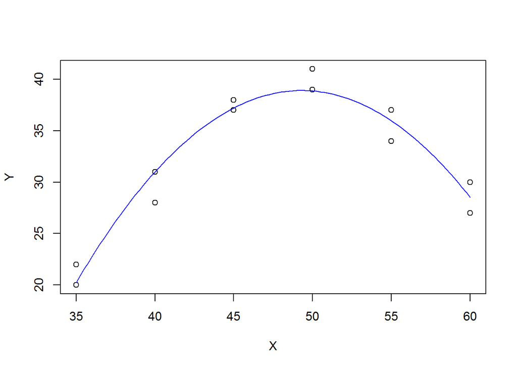

```r
plot(X, Y)
#lines(X, predict(fit), col="blue")
curve(-182.6+8.983*x-0.09107*x^2, 35, 60, col = "blue", add = TRUE)
```

The quadratic regression function appear to be a good fit.

## (b)

```r
b1 <- fit$coefficients[2]
b11 <- fit$coefficients[3]

X_max <- (-0.5)*b1/b11
X_max
```

```
##        X
## 49.31961
```

```r
Y_max <- sum(c(1, X_max, X_max^2)*coef(fit))
Y_max
```

```
## [1] 38.94216
```

$\hat{X}_{max}=49.32$

$E[Y]$ given $\hat{X}_{max}$ is 38.94

## (c)

```r
Y_hat <- predict(fit)
e <- Y-predict(fit)

n <- 1000
maxs <- vector(mode='numeric',length=n)
for(i in 1:n){
  Y_new <- Y_hat + sample(e, replace = TRUE)
  fit_new <- lm(Y_new~X+XX)
  b1_new <- fit_new$coefficients[2]
  b11_new <- fit_new$coefficients[3]
  maxs[i] <- (-0.5)*b1_new/b11_new
}
```

## (d)

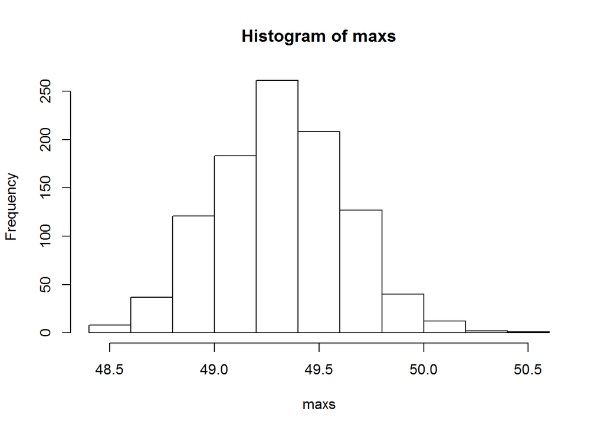

```r
hist(maxs)
```

The bootstrap sampling distribution of $\hat{X}_{max}^*$ appear to approximate normal distribution

## (e)

```r
xmax.05 <- quantile(maxs, 0.05)
xmax.95 <- quantile(maxs, 0.95)
xmax_var <- var(maxs)
d1 <- X_max - xmax.05
d2 <- xmax.95 - X_max
L <- X_max - d2
U <- X_max + d1
```

90 percent bootstrap confidence interval for Xmax using reflection method is [48.814, 49.820]